# Multivariate

Alexis

10/11/2021

```r
library("dplyr")
library("tidyr")
library("tidyverse")
library("ggplot2")
library("ezids")
library("gtsummary")
```

Importing and subsetting datafile

```r
dat <- data.frame(read.csv('datafile.csv'))
dat$AdoptionSpeed <- factor(dat$AdoptionSpeed, order=T, levels = c(0,1,2,3,4))
dat = subset(dat, dat$Quantity == 1)
dat = subset(dat, ! dat$AdoptionSpeed == 4)
dat = subset(dat, ! dat$MaturitySize == 0)
dat = subset(dat, ! dat$Gender == 3)

dat$Type = as.factor(dat$Type)
dat$Name = as.factor(dat$Name)
dat$Breed1 = as.factor(dat$Breed1)
dat$Breed2 = as.factor(dat$Breed2)
dat$Gender = as.factor(dat$Gender)
dat$Color1 = as.factor(dat$Color1)
dat$Color2 = as.factor(dat$Color2)
dat$Color3 = as.factor(dat$Color3)
dat$MaturitySize = as.factor(dat$MaturitySize)
dat$FurLength = as.factor(dat$FurLength)
dat$Vaccinated = as.factor(dat$Vaccinated)
dat$Dewormed = as.factor(dat$Dewormed)
dat$Sterilized = as.factor(dat$Sterilized)
dat$Health = as.factor(dat$Health)
dat$State = as.factor(dat$State)
```

```r
dat = subset(dat, select = - c(Health, State, Sterilized, Quantity, Dewormed, Color1, Color2, Color3, Breed1, Breed2, Fee, RescuerID, Name, Description, PetID, Type))
summary(dat)
```

Creating Randomized Dependent Variable

```r
# Adding random values
dat$ASnum = NaN
dat$ASnum[dat$AdoptionSpeed == 0] = 0
dat$ASnum[dat$AdoptionSpeed == 1] = runif(sum(dat$AdoptionSpeed == 1), 1, 7)
dat$ASnum[dat$AdoptionSpeed == 2] = runif(sum(dat$AdoptionSpeed == 2), 8, 30)
dat$ASnum[dat$AdoptionSpeed == 3] = runif(sum(dat$AdoptionSpeed == 3), 31, 90)
dat$ASnum[dat$AdoptionSpeed == 4] = 100
dat <- subset(dat, select = -c(AdoptionSpeed))
str(dat)
```

### SMART Question 3: What numerical variables influence adoption speed?

- Making linear models for each numerical variable

Age

```r
lm_age <- lm(ASnum ~ Age, data=dat )
table_lm_age <- tbl_regression(lm_age, intercept=TRUE)
table_lm_age
```

| **Characteristic** | **Beta** | **95% CI**<sup>1</sup> | **p-value** |
| --- | --- | --- | --- |
| (Intercept) | 26 | 25, 27 | <0.001 |
| Age | 0.06 | 0.03, 0.09 | <0.001 |

<sup>*1*</sup> CI = Confidence Interval

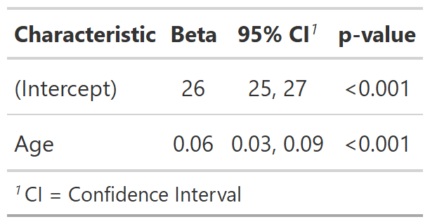

```r
table_lm_age %>%
  as_gt() %>%
  gt::gtsave(filename = "table_lm_age.png")
```

Statistically significant p-value, R-squared remains very low, Age alone does not predicate adoption speed.

Video Amount

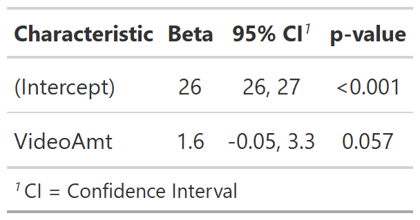

```r
lm_video <- lm(ASnum ~ VideoAmt, data=dat)
table_lm_video <- tbl_regression(lm_video, intercept=TRUE)
table_lm_video %>%
  as_gt() %>%
  gt::gtsave(filename = "table_lm_vide.png")
```

Not statistically significant, p-value > alpha.

Photo Amount

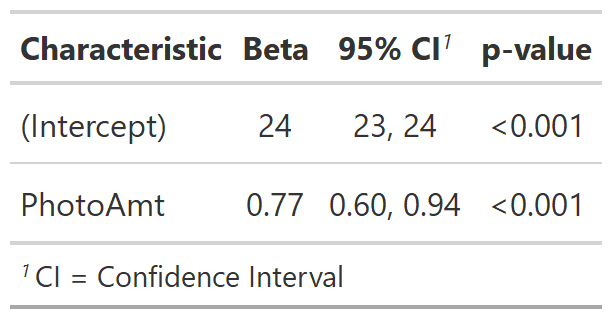

```r
lm_photo <- lm(ASnum ~ PhotoAmt, data=dat)
table_lm_photo <-tbl_regression(lm_photo, intercept=TRUE)
table_lm_photo %>%
  as_gt() %>%
  gt::gtsave(filename = "table_lm_photo.png")
```

#SMART Question 4: What combination of categorical and numerical variables result in the best predictive model?

First, lets look at the correlation plot of all numeric variables:

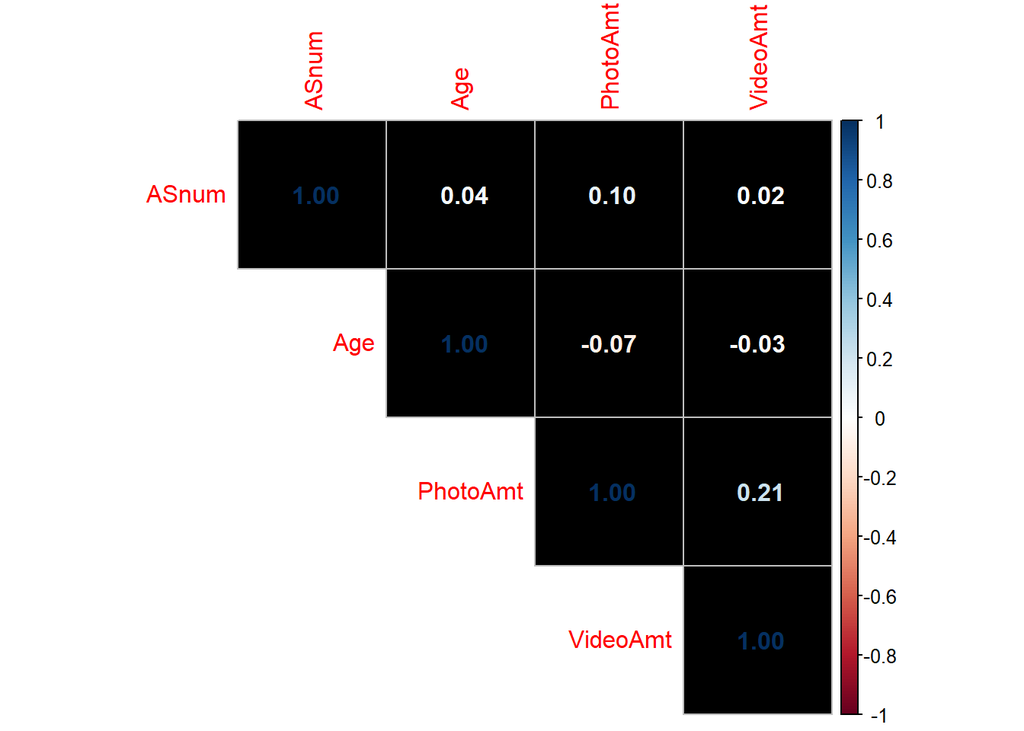

```r
library("corrplot")
dat_numerical <- subset(dat, select = c('ASnum','Age','PhotoAmt','VideoAmt'))
num_corr <- cor(dat_numerical)
corrplot(num_corr, method = "number", type="upper", bg='black')
```

- Super ugly corrplot, it might be the case that numerical variables aren’t that important??

Lets try a linear model with the three numerical independent variables against ASnum

```r
lm_num <- lm(ASnum ~ . , data=dat_numerical)
table_lm_num <- tbl_regression(lm_num, intercept=TRUE)
add_vif(table_lm_num, statistic="VIF")
```

| **Characteristic** | **Beta** | **95% CI**<sup>1</sup> | **p-value** | **VIF**<sup>1</sup> |
| --- | --- | --- | --- | --- |
| (Intercept) | 23 | 22, 24 | <0.001 |  |
| Age | 0.07 | 0.04, 0.10 | <0.001 | 1.0 |
| PhotoAmt | 0.80 | 0.63, 1.0 | <0.001 | 1.1 |
| VideoAmt | 0.04 | -1.7, 1.7 | >0.9 | 1.0 |

<sup>*1*</sup> CI = Confidence Interval, VIF = Variance Inflation Factor

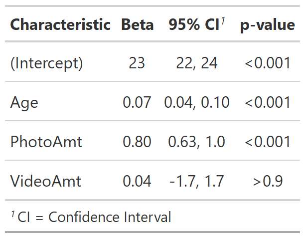

```r
table_lm_num %>%
  as_gt() %>%
  gt::gtsave(filename = "table_lm_num.png")
```

Ok, so PhotoAmt and Age are statistically relevant, but just using numerical values doesn’t really generate much predictive power, as evidenced by the rather low adjusted R-squared value.

Lets add in the remaining categorical variables

```r
lm_all <- lm(ASnum ~ ., data=dat)
lm_all_table <-tbl_regression(lm_all, intercept=TRUE)
add_vif(lm_all_table, statistic = "GVIF")
```

| **Characteristic** | **Beta** | **95% CI**<sup>1</sup> | **p-value** | **GVIF**<sup>1</sup> |
| --- | --- | --- | --- | --- |
| (Intercept) | 21 | 19, 23 | <0.001 |  |
| Age | 0.08 | 0.04, 0.11 | <0.001 | 1.2 |
| Gender |  |  |  | 1.0 |
| 1 | — | — |  |  |
| 2 | 2.7 | 1.6, 3.8 | <0.001 |  |
| MaturitySize |  |  |  | 1.1 |
| 1 | — | — |  |  |
| 2 | 5.6 | 4.2, 6.9 | <0.001 |  |
| 3 | 1.1 | -1.0, 3.3 | 0.3 |  |
| 4 | 3.4 | -6.0, 13 | 0.5 |  |
| FurLength |  |  |  | 1.1 |
| 1 | — | — |  |  |
| 2 | -2.6 | -3.8, -1.5 | <0.001 |  |
| 3 | -6.6 | -8.9, -4.4 | <0.001 |  |
| Vaccinated |  |  |  | 1.1 |
| 1 | — | — |  |  |
| 2 | -4.7 | -5.9, -3.5 | <0.001 |  |
| 3 | -0.85 | -2.6, 0.89 | 0.3 |  |
| VideoAmt | -0.09 | -1.8, 1.6 | >0.9 | 1.0 |
| PhotoAmt | 0.77 | 0.60, 0.94 | <0.001 | 1.1 |

<sup>*1*</sup> CI = Confidence Interval, GVIF = Generalized Variance Inflation Factor

```r
#lm_all_table%>%
  #as_gt() %>%
  #gt::gtsave(filename = "lm_all_table.png")
xkabledply(lm_all, title = paste("Model:", format(formula(lm_all)) ) )
```

Model: ASnum ~ Age + Gender + MaturitySize + FurLength + Vaccinated +

Model: VideoAmt + PhotoAmt

|  | Estimate | Std. Error | t value | Pr(>\|t\|) |
| --- | --- | --- | --- | --- |
| (Intercept) | 21.1201 | 0.9065 | 23.299 | 0.000 |
| Age | 0.0761 | 0.0165 | 4.621 | 0.000 |
| Gender2 | 2.7182 | 0.5507 | 4.936 | 0.000 |
| MaturitySize2 | 5.5568 | 0.6731 | 8.256 | 0.000 |
| MaturitySize3 | 1.1247 | 1.1004 | 1.022 | 0.307 |
| MaturitySize4 | 3.3975 | 4.7983 | 0.708 | 0.479 |
| FurLength2 | -2.6210 | 0.5826 | -4.499 | 0.000 |
| FurLength3 | -6.6470 | 1.1252 | -5.907 | 0.000 |
| Vaccinated2 | -4.6655 | 0.6174 | -7.556 | 0.000 |
| Vaccinated3 | -0.8531 | 0.8900 | -0.959 | 0.338 |
| VideoAmt | -0.0915 | 0.8586 | -0.106 | 0.915 |
| PhotoAmt | 0.7721 | 0.0872 | 8.851 | 0.000 |

```r
dat_lm <- subset(dat, select = -c(VideoAmt))
lm_subset1 <- lm(ASnum ~., data=dat_lm)
summary(lm_subset1)
```

[output not shown]

### Using feature selection tools to identify best model

```r
loadPkg("leaps")
reg_model <- regsubsets(ASnum~ Age + Gender + MaturitySize + FurLength + Vaccinated + VideoAmt + PhotoAmt, data = dat, nbest = 2, method = 'exhaustive')
```

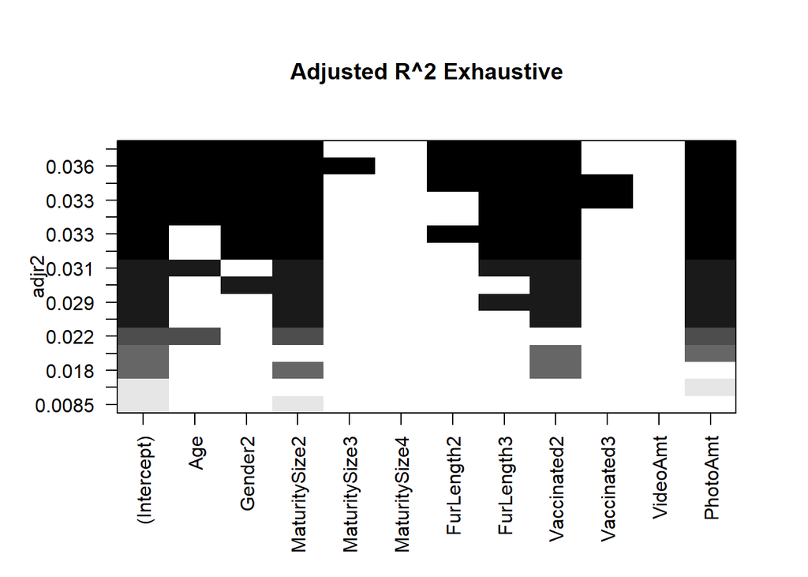

```r
plot(reg_model, scale = "adjr2", main = "Adjusted R^2 Exhaustive")
```

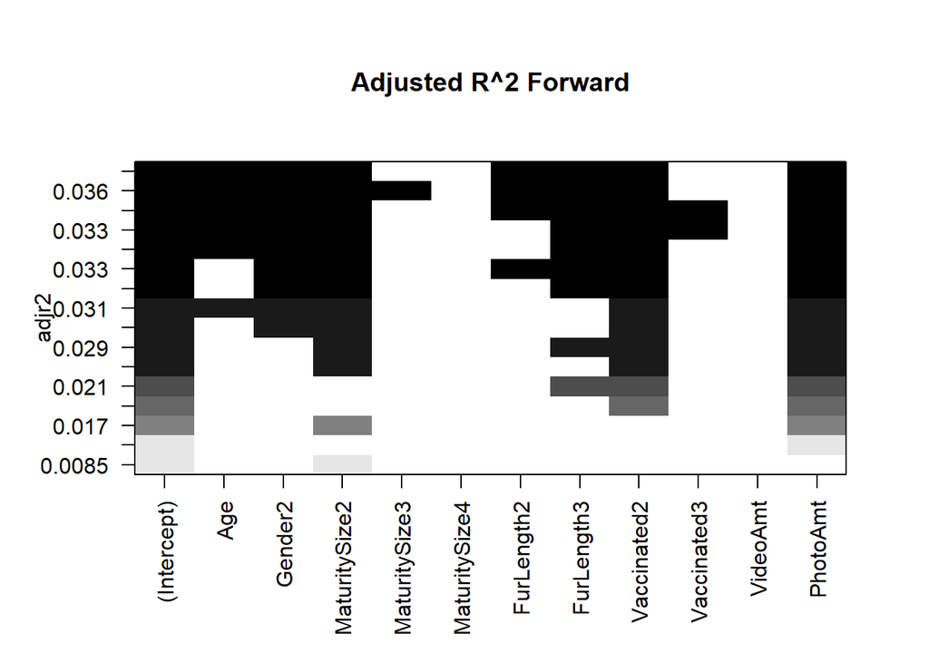

```r
reg_model_forward <- regsubsets(ASnum~ Age + Gender + MaturitySize + FurLength + Vaccinated + VideoAmt + PhotoAmt, data = dat, nbest = 2, method = 'forward')
plot(reg_model_forward, scale = "adjr2", main = "Adjusted R^2 Forward")
```

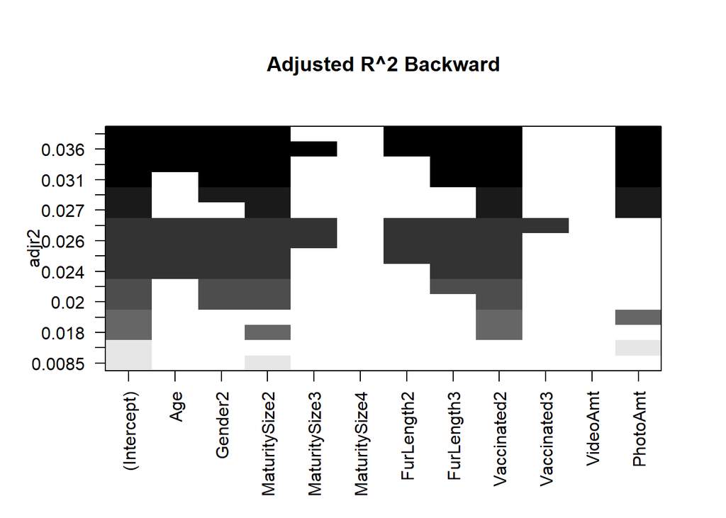

```r
reg_model_backward <- regsubsets(ASnum~ Age + Gender + MaturitySize + FurLength + Vaccinated + VideoAmt + PhotoAmt, data = dat, nbest = 2, method = 'backward')
plot(reg_model_backward, scale = "adjr2", main = "Adjusted R^2 Backward")
```

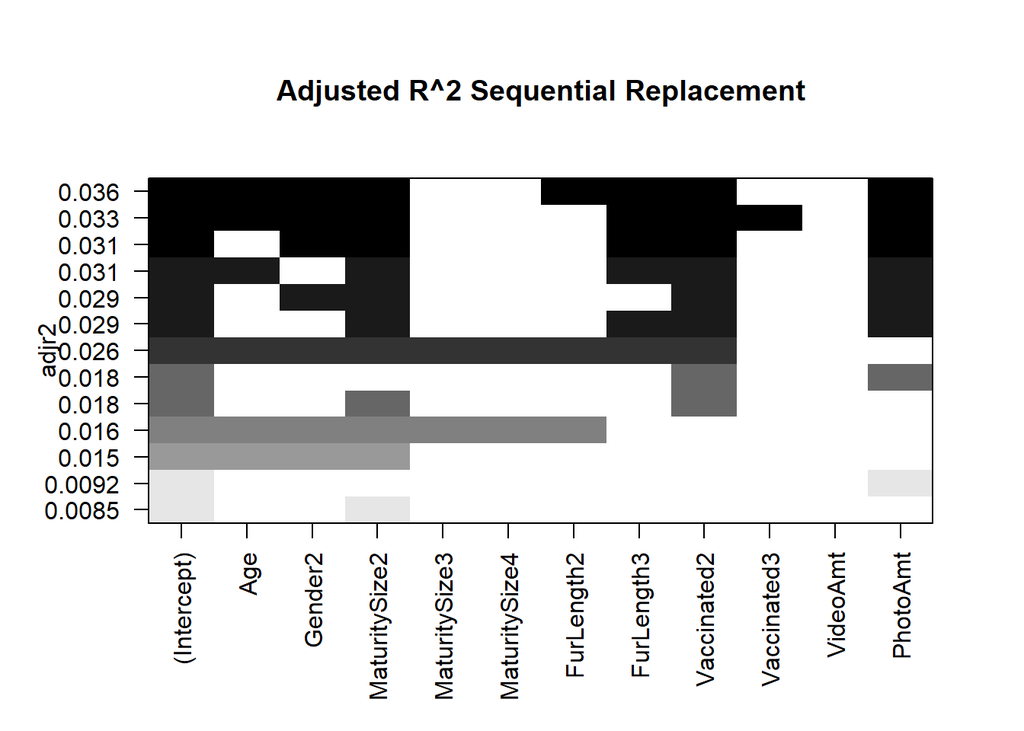

```r
reg_model_sequential <- regsubsets(ASnum~ Age + Gender + MaturitySize + FurLength + Vaccinated + VideoAmt + PhotoAmt, data = dat, nbest = 2, method = 'seqrep')
plot(reg_model_sequential, scale = "adjr2", main = "Adjusted R^2 Sequential Replacement")
```

No difference in variables between exhaustive, forward, and backward selection: Age, Gender 2, MaturitySize2, MaturitySize3, FurLength2, Furlength3, Vaccinated2, and PhotoAmt

```r
dat_drop_mat_4 <- subset(dat, ! dat$MaturitySize == 4)
dat_drop_mat_4 <- subset(dat_drop_mat_4, ! dat_drop_mat_4$Vaccinated== 3 )
dat_drop_mat_4_3 <- subset(dat_drop_mat_4, ! dat_drop_mat_4$MaturitySize == 3)
exh_for_back_model <- lm(ASnum~ Age + Gender + MaturitySize + FurLength + Vaccinated + PhotoAmt, data=dat_drop_mat_4)
table_exh_for_back_model <- tbl_regression(exh_for_back_model, intercept=TRUE)
add_vif(table_exh_for_back_model, statistic = "GVIF")
```

| **Characteristic** | **Beta** | **95% CI**<sup>1</sup> | **p-value** | **GVIF**<sup>1</sup> |
| --- | --- | --- | --- | --- |
| (Intercept) | 21 | 19, 23 | <0.001 |  |
| Age | 0.08 | 0.04, 0.12 | <0.001 | 1.2 |
| Gender |  |  |  | 1.0 |
| 1 | — | — |  |  |
| 2 | 2.9 | 1.8, 4.1 | <0.001 |  |
| MaturitySize |  |  |  | 1.1 |
| 1 | — | — |  |  |
| 2 | 5.2 | 3.8, 6.7 | <0.001 |  |
| 3 | 1.1 | -1.2, 3.5 | 0.3 |  |
| FurLength |  |  |  | 1.1 |
| 1 | — | — |  |  |
| 2 | -2.8 | -4.0, -1.6 | <0.001 |  |
| 3 | -6.1 | -8.5, -3.6 | <0.001 |  |
| Vaccinated |  |  |  | 1.1 |
| 1 | — | — |  |  |
| 2 | -4.6 | -5.8, -3.4 | <0.001 |  |
| PhotoAmt | 0.78 | 0.61, 1.0 | <0.001 | 1.0 |

<sup>*1*</sup> CI = Confidence Interval, GVIF = Generalized Variance Inflation Factor

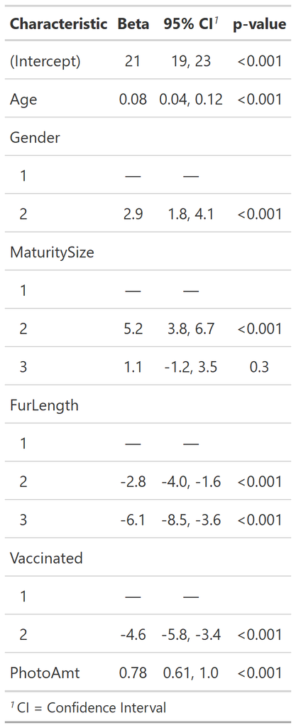

```r
table_exh_for_back_model %>%
  as_gt() %>%
  gt::gtsave(filename = "table_exh_for_back_model.png")
```

```r
xkabledply(exh_for_back_model, title = paste("Model:", format(formula(exh_for_back_model)) ) )
```

Model: ASnum ~ Age + Gender + MaturitySize + FurLength + Vaccinated +

Model: PhotoAmt

|  | Estimate | Std. Error | t value | Pr(>\|t\|) |
| --- | --- | --- | --- | --- |
| (Intercept) | 21.1618 | 0.9532 | 22.20 | 0.000 |
| Age | 0.0792 | 0.0185 | 4.29 | 0.000 |
| Gender2 | 2.9054 | 0.5873 | 4.95 | 0.000 |
| MaturitySize2 | 5.2447 | 0.7235 | 7.25 | 0.000 |
| MaturitySize3 | 1.1432 | 1.2031 | 0.95 | 0.342 |
| FurLength2 | -2.8010 | 0.6202 | -4.52 | 0.000 |
| FurLength3 | -6.0876 | 1.2453 | -4.89 | 0.000 |
| Vaccinated2 | -4.5961 | 0.6242 | -7.36 | 0.000 |
| PhotoAmt | 0.7811 | 0.0876 | 8.92 | 0.000 |

```r
xkablevif(exh_for_back_model)
```

VIFs of the model

| Age | FurLength2 | FurLength3 | Gender2 | MaturitySize2 | MaturitySize3 | PhotoAmt | Vaccinated2 |
| --- | --- | --- | --- | --- | --- | --- | --- |
| 1.21 | 1.01 | 1.3 | 1.32 | 1.05 | 1.11 | 1.14 | 1.01 |

```r
summary(exh_for_back_model)
```

```
##
## Call:
## lm(formula = ASnum ~ Age + Gender + MaturitySize + FurLength +
##     Vaccinated + PhotoAmt, data = dat_drop_mat_4)
##
## Residuals:
##    Min     1Q Median     3Q    Max
## -47.76 -19.10  -8.33  12.57  72.77
##
## Coefficients:
##               Estimate Std. Error t value Pr(>|t|)
## (Intercept)    21.1618     0.9532   22.20  < 2e-16 ***
## Age             0.0792     0.0185    4.29  1.8e-05 ***
## Gender2         2.9054     0.5873    4.95  7.7e-07 ***
## MaturitySize2   5.2447     0.7235    7.25  4.6e-13 ***
## MaturitySize3   1.1432     1.2031    0.95     0.34
## FurLength2     -2.8010     0.6202   -4.52  6.4e-06 ***
## FurLength3     -6.0876     1.2453   -4.89  1.0e-06 ***
## Vaccinated2    -4.5961     0.6242   -7.36  2.0e-13 ***
## PhotoAmt        0.7811     0.0876    8.92  < 2e-16 ***
## ---
## Signif. codes:  0 '***' 0.001 '**' 0.01 '*' 0.05 '.' 0.1 ' ' 1
##
## Residual standard error: 25.1 on 7404 degrees of freedom
## Multiple R-squared:  0.0381, Adjusted R-squared:  0.037
## F-statistic: 36.6 on 8 and 7404 DF,  p-value: <2e-16
```

```r
sequential_model <- lm(ASnum ~ Gender + MaturitySize + FurLength + Vaccinated + PhotoAmt, data=dat_drop_mat_4_3)
table_sequential_model <- tbl_regression(sequential_model, intercept=TRUE)
add_vif(table_sequential_model, statistic = "GVIF")
```

| **Characteristic** | **Beta** | **95% CI**<sup>1</sup> | **p-value** | **GVIF**<sup>1</sup> |
| --- | --- | --- | --- | --- |
| (Intercept) | 23 | 21, 25 | <0.001 |  |
| Gender |  |  |  | 1.0 |
| 1 | — | — |  |  |
| 2 | 3.0 | 1.7, 4.2 | <0.001 |  |
| MaturitySize |  |  |  | 1.0 |
| 1 | — | — |  |  |
| 2 | 4.9 | 3.5, 6.4 | <0.001 |  |
| FurLength |  |  |  | 1.0 |
| 1 | — | — |  |  |
| 2 | -2.8 | -4.1, -1.5 | <0.001 |  |
| 3 | -5.6 | -8.4, -2.9 | <0.001 |  |
| Vaccinated |  |  |  | 1.0 |
| 1 | — | — |  |  |
| 2 | -5.7 | -6.9, -4.5 | <0.001 |  |
| PhotoAmt | 0.72 | 0.54, 0.89 | <0.001 | 1.0 |

<sup>*1*</sup> CI = Confidence Interval, GVIF = Generalized Variance Inflation Factor

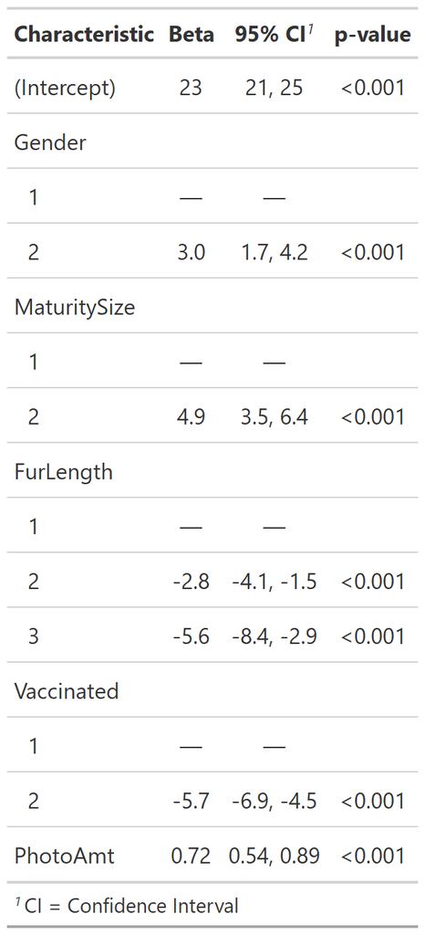

```r
table_sequential_model %>%
  as_gt() %>%
  gt::gtsave(filename = "table_sequential_model.png")
```

```r
xkabledply(sequential_model, title = paste("Model:", format(formula(exh_for_back_model)) ) )
```

|  | Estimate | Std. Error | t value | Pr(>\|t\|) |
| --- | --- | --- | --- | --- |
| (Intercept) | 22.867 | 0.9146 | 25.00 | 0 |
| Gender2 | 2.953 | 0.6138 | 4.81 | 0 |
| MaturitySize2 | 4.940 | 0.7211 | 6.85 | 0 |
| FurLength2 | -2.791 | 0.6458 | -4.32 | 0 |
| FurLength3 | -5.636 | 1.3868 | -4.06 | 0 |
| Vaccinated2 | -5.665 | 0.6149 | -9.21 | 0 |
| PhotoAmt | 0.716 | 0.0912 | 7.85 | 0 |

```r
xkablevif(sequential_model)
```

VIFs of the model

| FurLength2 | FurLength3 | Gender2 | MaturitySize2 | PhotoAmt | Vaccinated2 |
| --- | --- | --- | --- | --- | --- |
| 1 | 1.01 | 1.04 | 1.04 | 1.01 | 1 |

```r
summary(sequential_model)
```

```
##
## Call:
## lm(formula = ASnum ~ Gender + MaturitySize + FurLength + Vaccinated +
##     PhotoAmt, data = dat_drop_mat_4_3)
##
## Residuals:
##    Min     1Q Median     3Q    Max
## -47.02 -19.19  -8.23  12.95  72.56
##
## Coefficients:
##               Estimate Std. Error t value Pr(>|t|)
## (Intercept)    22.8675     0.9146   25.00  < 2e-16 ***
## Gender2         2.9526     0.6138    4.81  1.5e-06 ***
## MaturitySize2   4.9397     0.7211    6.85  8.0e-12 ***
## FurLength2     -2.7914     0.6458   -4.32  1.6e-05 ***
## FurLength3     -5.6360     1.3868   -4.06  4.9e-05 ***
## Vaccinated2    -5.6651     0.6149   -9.21  < 2e-16 ***
## PhotoAmt        0.7157     0.0912    7.85  5.0e-15 ***
## ---
## Signif. codes:  0 '***' 0.001 '**' 0.01 '*' 0.05 '.' 0.1 ' ' 1
##
## Residual standard error: 25.1 on 6781 degrees of freedom
## Multiple R-squared:  0.0359, Adjusted R-squared:  0.0351
## F-statistic: 42.1 on 6 and 6781 DF,  p-value: <2e-16
```